# Lab1

Priya Shaji

February 4, 2019

Load the cdc dataset

```r
source("more/cdc.R")
```

view the names of the variables

```r
dim(cdc)
```

```
## [1] 20000     9
```

```r
names(cdc)
```

```
## [1] "genhlth"  "exerany"  "hlthplan" "smoke100" "height"   "weight"
## [7] "wtdesire" "age"      "gender"
```

## EXERCISE 1

How many cases are there in this data set? How many variables? For each variable, identify its data type (e.g. categorical, discrete).

Answer 1.

Cases: 20,000  
variables: 9 Data Type of each variable genhlth - Categorical exerany - Categorical hlthplan - Categorical smoke100 - Categorical height - Numeric, continuous weight - Numeric, continuous wtdesire - Numeric, continuous age - Numeric, discrete(since age can take only integer values, therefore it’s discrete) gender - Categorical

First few entries (rows) of our data

```r
head(cdc)
```

```
##     genhlth exerany hlthplan smoke100 height weight wtdesire age gender
## 1      good       0        1        0     70    175      175  77      m
## 2      good       0        1        1     64    125      115  33      f
## 3      good       1        1        1     60    105      105  49      f
## 4      good       1        1        0     66    132      124  42      f
## 5 very good       0        1        0     61    150      130  55      f
## 6 very good       1        1        0     64    114      114  55      f
```

Last few entries (rows) of our data

```r
tail(cdc)
```

```
##         genhlth exerany hlthplan smoke100 height weight wtdesire age
## 19995      good       0        1        1     69    224      224  73
## 19996      good       1        1        0     66    215      140  23
## 19997 excellent       0        1        0     73    200      185  35
## 19998      poor       0        1        0     65    216      150  57
## 19999      good       1        1        0     67    165      165  81
## 20000      good       1        1        1     69    170      165  83
##       gender
## 19995      m
## 19996      f
## 19997      m
## 19998      f
## 19999      f
## 20000      m
```

summary of column weight

```r
summary(cdc$weight)
```

```
##    Min. 1st Qu.  Median    Mean 3rd Qu.    Max.
##    68.0   140.0   165.0   169.7   190.0   500.0
```

calculate the mean, median, and variance of weight

```r
mean(cdc$weight)
```

```
## [1] 169.683
```

```r
var(cdc$weight)
```

```
## [1] 1606.484
```

```r
median(cdc$weight)
```

```
## [1] 165
```

For categorical data, we consider their sample frequency or relative frequency distribution For example, to see the number of people who have smoked 100 cigarettes in their lifetime

```r
table(cdc$smoke100)
```

```
##
##     0     1
## 10559  9441
```

```r
table(cdc$smoke100)/20000
```

```
##
##       0       1
## 0.52795 0.47205
```

bar plot of the entries in the table

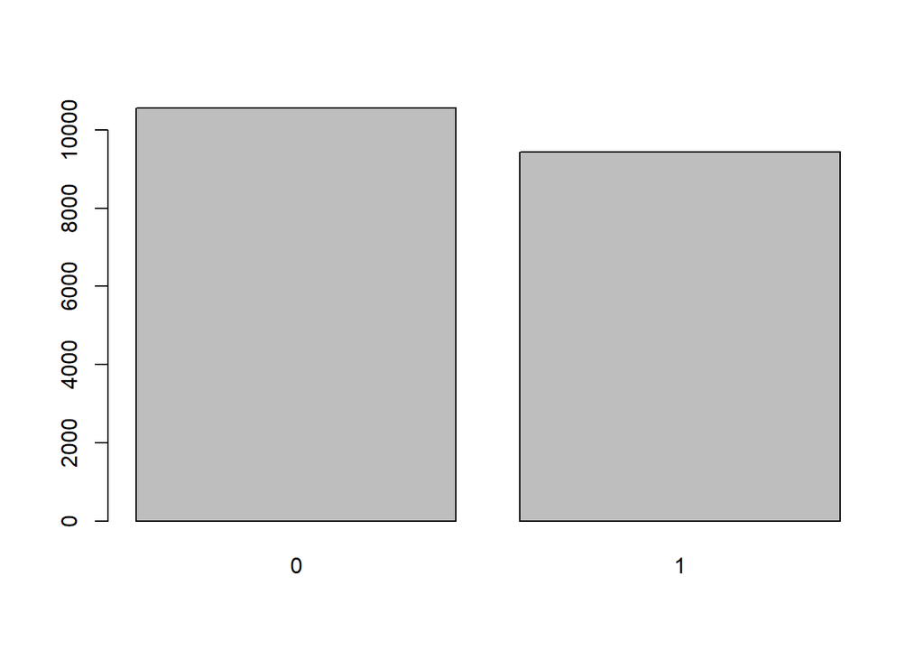

```r
barplot(table(cdc$smoke100))
```